# Conformal Inference for Personalized Imputation. A simulation study

Marcos Matabuena

Carla Díaz-Louzao

Rahul Ghosal

Francisco Gude-Sampedro# Authors of the document

October 15, 2023

# 1 Introduction

In this document, we present the simulation study for imputing missing functional responses using Wasserstein Regression and a conformal estimation of the 95% confidence bands.

```r
rm(list = ls())

###################################################################################################################
################################################ LOADING LIBRARIES ################################################
###################################################################################################################

.libPaths(c("C:/Users/Carla/Documents/R/win-library/4.3", .libPaths() ) )
library(boot)
library(ggplot2)
library(mgcv)

source("I:/Conformal_Imputation_Glucodensities/Scripts/functions.R")
source("I:/Conformal_Imputation_Glucodensities/Scripts/glucodensities_missing.R")
```

# 2 Theoretical aspects

## 2.1 Generation of the simulated data

We are working with a linear mechanism for the probability that the response is not missing and two covariates. This means that the probability of not being missing depends on two covariates via a linear model, and it is computed as the inverse logit function applied to the linear predictor $p$ of that model, i.e.:
$$p_{miss} = \frac{\exp(p)}{\left(1+\exp(p)\right)}.$$

We are considering the size of the database to be n = 500, and computing R = 500 samples. For each $i \in \{1, \dots, n\}$, the linear model for the probability that the response is not missing:
$$p_i = −0.75 + 1.89X_{1i} − 0.37X_{2i}.$$
With this model, the mean probability that the response is not missing for all the 500 samples is $\bar{p}_{miss} = 0.5$.

## 2.2 Imputation step with missing responses and 2-Wassertein metric

### 2.2.1 Computation of the weights

The metholody proposed includes inverse probability weighting in the estimations, these weights being based on the probability that the response is not missing. Since in practice we do not know the model generating this probability, we have decided to use in all cases a generalized additive model for binary response, with the same covariates as the main model, using the *mgcv* R package (Wood 2017).

Let $A$ be the indicator that the response is not missing:
$$A = \begin{cases}
0 & \text{if the functional outcome is missing,} \\
1 & \text{if the functional outcome is observed.}
\end{cases}$$
Let also $X_j$ be the covariates available at our disposal, with $j \in \{1, 2\}$. Then, the estimated probability of not being missing is computed according the following model:
$$A \sim X_1 + X_2$$
The linear predictors obtained are then inverted and multiplied by $A$. Thus, for every individual $i \in \{1, \dots, n = 500\}$, the weights are as follows:
$$w_i = \frac{\mathbf{1}_{A_i = 1}}{lp^w_i} = \begin{cases}
0 & \text{if the outcome is missing}, \\
\frac{1}{lp^w_i} & \text{if the outcome is known},
\end{cases}$$
where $lp^w$ is the linear predictor for the weights.

### 2.2.2 Imputation of missing responses and marginal coverage conformal inference

We imputed missing responses by simply estimating them based on the (Wasserstein-)Fréchet model fitted to the sample with complete observations. As we also applied marginal coverage conformal inference for estimating the 95% confidence intervals.

## 2.3 Evaluation of the performance of the simulations

Performance will be evaluated according to 3 criteria:

- **Coverage**: As previously explained, we imputed the missing responses and estimate the confidence intervals using conformal inference. We considered that the estimated confidence interval completely covered a curve if all points on the curve are in that interval. For this, we calculated the 95th percentile to compute the confidence intervals.
- $\mathbf{R^2}$: The performance of the (Wasserstein-)Fréchet model was evaluated by means of the $R^2$, defined as follows:
  $$R^2 = 1 - \frac{||\mathbf{Y}_{tr} - \mathbf{\hat{Y}}_{tr}||^2}{||\mathbf{Y}_{tr} - \mathbf{\bar{Y}}_{tr}||^2},$$
  where $\mathbf{\hat{Y}}_tr$ is the matrix with the estimations over the train dataset obtained by the model and $\mathbf{\bar{Y}}_{tr}$ is a mean matrix with the man response vector of $\mathbf{Y}_{tr}$.
- **RMSE**: We computed the Root Mean Squared Error (RMSE) for all runs as in the following:
  $$RMSE = \sqrt{\frac{1}{50|I_{test}|}\sum_{i \in I_{test}}{\sum_{k = 1}^{50}{(Y_{test,ik} - \hat{Y}_{test,ik})^2}}},$$
  where 50 is the number of observations for each functional outcome, $|I_{test}|$ is the cardinal of the test fold, $Y_{test,ij}$ is the real value for the ``missing’’ outcome of individual $i \in I_{test}$ at point $k$, and $\hat{Y}_{test,ij}$ is the estimation at that point.

The variance of the expected error depends on the number of covariates used to generate the outcomes, in our case this number is 2. With this in mind, we calculate that, if the model has a good fit, for the case of 2 covariates this error is around 0.069.

# 3 Application

## 3.1 Simulations

Here we compute the simulations and calculate the performance metrics.

```r
R = 500 # number of samples
py = 50 # length of the grid
t = seq(0, 1, length = py) # grid for the quantiles
SNR <- 30

std <- numeric(R)
coverage <- numeric(R)
res <- list(coverage, coverage, coverage)
names(res) <- c("coverage", "r2","rmse")

for(i in 1:R){
    X = matrix(runif(500 * 2), ncol = 2, nrow = 500) # Generation of the covariates
    out = matrix(0, nrow = 500, ncol = py)

    for(j in 1:py){
      out[, j] = apply(X, 1, sum) * t[j] # Generation of the response (without error)
    }
    std[i] <- sd(as.vector(out))/sqrt(SNR)
    out <- out + sd(as.vector(out))/sqrt(SNR) * matrix(rep(rnorm(500, 0, 1), times = py), ncol = py) # Adding the error term to the response

    data1 = as.data.frame(X)
    colnames(data1) = paste("X", 1:2, sep = "")
    nombres <- names(data1)
    Y <- out
    colnames(Y) = paste("Y", 1:py, sep = "")

    data1$Y = Y

    f1 <- paste0("Y ~ ", paste(nombres, collapse = " + ")) # Formula for the Wasserstein model
    f <- formula(paste0("p ~ ", paste(paste0("s(", nombres, ")"), collapse = " + "))) # Formula for the weights

    error <- T # This error is introduced because sometimes the rbinom produces a lot of 1 (very high proportion of "missing" responses), wich leads to an error when adjustin the Wasserstein model. When this happens, rbinom is executed again.
    ############################################
    while(error == T){
      coef <- c(1.89, -0.37)
      data1$p <- rbinom(500, 1, inv.logit(as.matrix(data1[, 1:2])%*%coef - 0.75)) # 0.75 is the intercept of the model

      mod <- gam(f, data = data1, family = "binomial") # binomial model for the weights
      data1$weights <- as.numeric(as.character(data1$p))/mod$fitted.values

      dat0 <- data1[data1$p == 0, ] # Test set
      dat1 <- data1[data1$p == 1, ] # Train set

      tryCatch({
        m <- concurrentconformal(formula = f1, prob = 0.95, xpred = dat0, var_weights = weights, data = dat1, plot = F)
        error <- F
      }, error = function(e){ })
    }
    save(m, file = paste0("I:/Conformal_Imputation_Glucodensities/simulations/models/m_linear_500_2_", i, ".RData"))

    #' Coverage of the confidence bands
    coverage <- 0
    for(j in 1:dim(dat0)[1]){
      for(k in 1:py){
        if(dat0$Y[j, k] <= m$lower[j, k] | dat0$Y[j, k] >= m$upper[j, k]){
          coverage <- coverage + 1
          break
        }
      }
    }
    rm(j)
    rm(k)
    res$coverage[i] <- 1 - coverage/dim(dat0)[1]

    #' R^2
    res$r2[i] <- m$r2

    #' RMSE
    res$rmse[i] <- sqrt(mean((dat0$Y - m$Yest)^2))

    save(data1, file = paste0("I:/Conformal_Imputation_Glucodensities/simulations/data/dat_linear_500_2_", i, ".RData"))
}

save(res, file = "I:/Conformal_Imputation_Glucodensities/simulations/results/m_linear_500_2_500.RData")
```

## 3.2 Results

Here we show the perfomance measurements of the simulated data.

```r
# load(paste0("I:/Conformal_Imputation_Glucodensities/simulations/results/m_linear_500_2_500.RData"))
df <- data.frame(Coverage = res$coverage, R2 = res$r2, RMSE = res$rmse, type = "Model")

df$id <- rep(1:500)
db <- gather(df, key = "measure", value = "value", c("Coverage" , "R2" ,"RMSE"))
db_coverage <- db[db$measure == "Coverage", ]
db_r2 <- db[db$measure == "R2", ]
db_rmse <- db[db$measure == "RMSE", ]
```

### 3.2.1 Coverage

Although we have calculated the 95th percentile to compute the confidence, the coverage provided by them was not 95%. In Figure 3.1 we show the coverage for the simulation scenario proposed. As expected, since the missing response mechanism depends on the covariates, the median coverage is somewhat lower 95% (90.58%). It was to be expected that coverage would drop in these cases, as it is known that conformal inference is not accurate for cases where the exact weights are unknown and must be estimated, but even so the reduction is small.

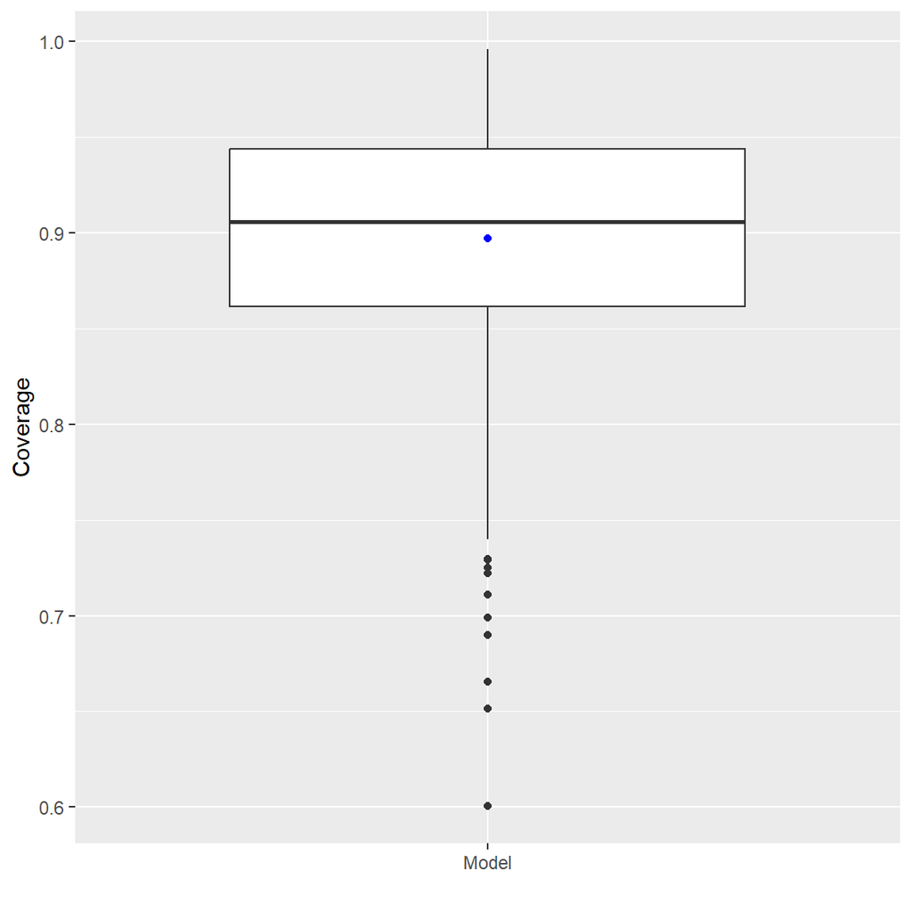

Figure 3.1: Boxplot of the coverage provided by the conformal inference for 500 runs in the proposed simulation scenario. The blue point indicates the mean value.

```r
ggplot(db_coverage, aes(x = type, y = value)) +
  geom_boxplot() +
  xlab(" ") +
  ylab("Coverage") +
  stat_summary(geom = "point", fun = "mean", col = "blue",
                   position = position_dodge(width = 0.75), aes(x = type, y = value))
```

### 3.2.2 R squared

The main insight we obtained from the experiments is that the method seems to be pretty robust, since, as we can see in Figure 3.2, the median $R^2$ of all 500 runs is 0.87, with a narrow interquartile rank (0.84-0.89).

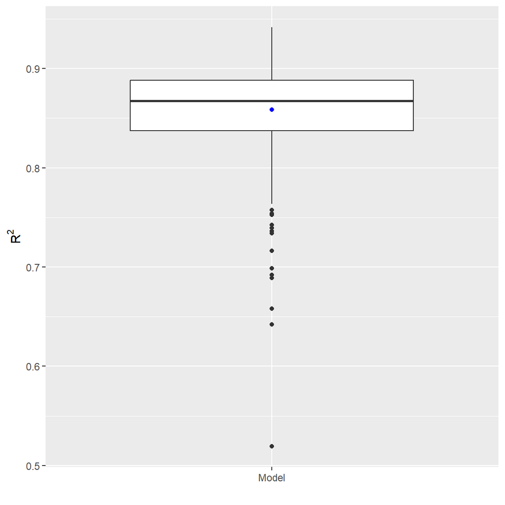

Figure 3.2: Boxplot of the R-squared from the (Wasserstein-)Fréchet model for 500 runs in the proposed simulation scenario. The blue point indicates the mean value

```r
ggplot(db_r2, aes(x = type, y = value)) +
  geom_boxplot() +
  xlab(" ") +
  ylab(expression(R^2)) +
  stat_summary(geom = "point", fun = "mean", col = "blue",
                   position = position_dodge(width = 0.75), aes(x = type, y = value))
```

### 3.2.3 RMSE

Finaly, Results are shown in Figure 3.3. As we already stated, the expected RMSE was 0.069. The median RMSE is 0.091.

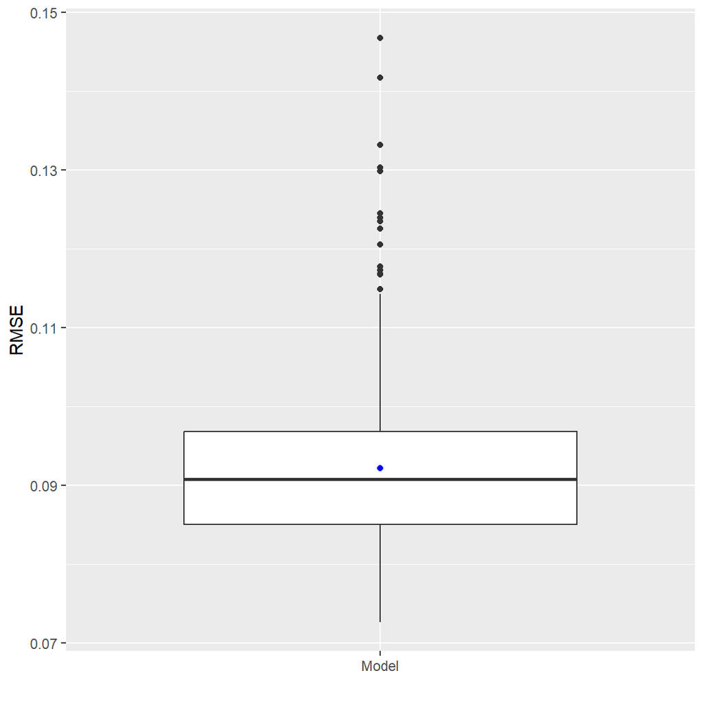

Figure 3.3: Boxplot of the Root Mean Squared Error (RMSE) from the (Wasserstein-)Fréchet model for 500 runs in the proposed simulation scenario. The blue point indicates the mean value

```r
ggplot(db_rmse, aes(x = type, y = value)) +
  geom_boxplot() +
  xlab(" ") +
  ylab("RMSE") +
  stat_summary(geom = "point", fun = "mean", col = "blue",
                   position = position_dodge(width = 0.75), aes(x = type, y = value))
```

Wood, S. N. (2017), *Generalized additive models: An introduction with R*, CRC press. https://doi.org/10.1201/9781420010404.